# Introduction to Computer Vision: Plant Seedlings Classification

## Problem Statement

### Context

In recent times, the field of agriculture has been in urgent need of modernizing, since the amount of manual work people need to put in to check if plants are growing correctly is still highly extensive. Despite several advances in agricultural technology, people working in the agricultural industry still need to have the ability to sort and recognize different plants and weeds, which takes a lot of time and effort in the long term. The potential is ripe for this trillion-dollar industry to be greatly impacted by technological innovations that cut down on the requirement for manual labor, and this is where Artificial Intelligence can actually benefit the workers in this field, as **the time and energy required to identify plant seedlings will be greatly shortened by the use of AI and Deep Learning.** The ability to do so far more efficiently and even more effectively than experienced manual labor, could lead to better crop yields, the freeing up of human inolvement for higher-order agricultural decision making, and in the long term will result in more sustainable environmental practices in agriculture as well.

### Objective

The aim of this project is to Build a Convolutional Neural Netowrk to classify plant seedlings into their respective categories.

### Data Dictionary

The Aarhus University Signal Processing group, in collaboration with the University of Southern Denmark, has recently released a dataset containing **images of unique plants belonging to 12 different species.**

- The dataset can be download from Olympus.
- The data file names are:
  - images.npy
  - Label.csv
- Due to the large volume of data, the images were converted to the images.npy file and the labels are also put into Labels.csv, so that you can work on the data/project seamlessly without having to worry about the high data volume.
- The goal of the project is to create a classifier capable of determining a plant's species from an image.

**List of Species**

- Black-grass
- Charlock
- Cleavers
- Common Chickweed
- Common Wheat
- Fat Hen
- Loose Silky-bent
- Maize
- Scentless Mayweed
- Shepherds Purse
- Small-flowered Cranesbill
- Sugar beet

#### **Note: Please use GPU runtime to execute the code efficiently**

## Importing necessary libraries

```python
import numpy as np
import pandas as pd
import seaborn as sns
import random
import matplotlib.pyplot as plt
import tensorflow as tf
import cv2
from sklearn.preprocessing import LabelEncoder
from tensorflow import keras
from tensorflow.keras import layers, models
from sklearn.model_selection import train_test_split
from sklearn.metrics import classification_report, confusion_matrix, accuracy_score
from sklearn.utils.multiclass import unique_labels
from tensorflow.keras.callbacks import ReduceLROnPlateau
from tensorflow.keras.applications import VGG16
from tensorflow.keras.layers import Dense, Flatten
from tensorflow.keras.models import Model
from tensorflow.keras.preprocessing.image import ImageDataGenerator
```

## Loading the dataset

```python
# Mount Google drive to access the dataset
# Run the below code if you using google colab
from google.colab import drive
drive.mount('/content/drive')
```

```python
labels = pd.read_csv('/content/drive/MyDrive/Labels.csv')
images = np.load('/content/drive/MyDrive/images.npy')
```

## Data Overview

### Understand the shape of the dataset

```python
labels.info()
```

```
<class 'pandas.core.frame.DataFrame'>
RangeIndex: 4750 entries, 0 to 4749
Data columns (total 1 columns):
 #   Column  Non-Null Count  Dtype
---  ------  --------------  -----
 0   Label   4750 non-null   object
dtypes: object(1)
memory usage: 37.2+ KB
```

```python
labels['Label'].unique()
```

```
array(['Small-flowered Cranesbill', 'Fat Hen', 'Shepherds Purse',
       'Common wheat', 'Common Chickweed', 'Charlock', 'Cleavers',
       'Scentless Mayweed', 'Sugar beet', 'Maize', 'Black-grass',
       'Loose Silky-bent'], dtype=object)
```

```python
labels['Label'].value_counts()
```

```
Loose Silky-bent             654
Common Chickweed             611
Scentless Mayweed            516
Small-flowered Cranesbill    496
Fat Hen                      475
Charlock                     390
Sugar beet                   385
Cleavers                     287
Black-grass                  263
Shepherds Purse              231
Common wheat                 221
Maize                        221
Name: Label, dtype: int64
```

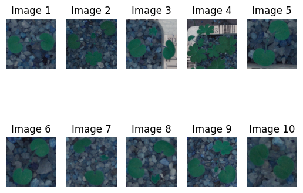

```python
num_images_to_preview = 10

# Iterate through the first 10 images and display them
for i in range(num_images_to_preview):
    plt.subplot(2, 5, i + 1)  # Create a 2x5 grid of subplots
    plt.imshow(images[i])  # Display the image
    plt.title(f"Image {i+1}")
    plt.axis('off')  # Turn off axis labels

plt.show()
```

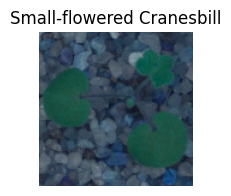

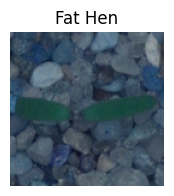

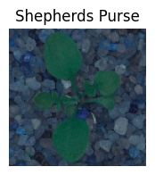

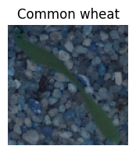

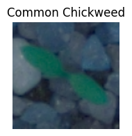

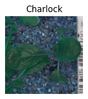

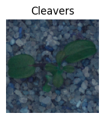

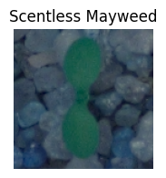

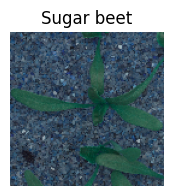

[figure not shown]

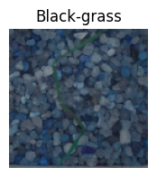

[figure not shown]

```python
# Create a dictionary to store a random image for each label
random_images = {}

# Iterate through each unique label
for label in labels['Label'].unique():
    # Get all indices where the label matches
    label_indices = labels[labels['Label'] == label].index.tolist()

    # Choose a random index
    random_index = random.choice(label_indices)

    # Get the corresponding image from the 'images' array
    random_image = images[random_index]

    # Add the random image to the dictionary
    random_images[label] = random_image

# Plot and print the random images with their corresponding labels
for label, random_image in random_images.items():
    plt.figure(figsize=(2, 2))
    plt.imshow(random_image)
    plt.title(label)
    plt.axis('off')
    plt.show()
```

## Exploratory Data Analysis

- EDA is an important part of any project involving data.
- It is important to investigate and understand the data better before building a model with it.
- A few questions have been mentioned below which will help you understand the data better.
- A thorough analysis of the data, in addition to the questions mentioned below, should be done.
1. How are these different category plant images different from each other?
2. Is the dataset provided an imbalance? (Check with using bar plots)

The images have different zoom depths. Some have pepples in the background and some have pepples as well as other objects like barcodes and stickers.

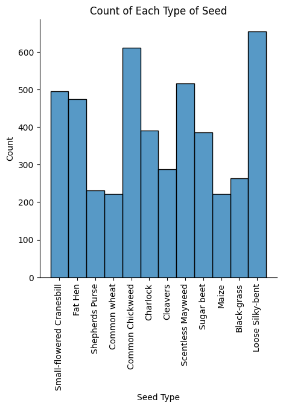

```python
plt.figure(figsize=(10, 6))
sns.displot(data=labels, x='Label')
plt.title('Count of Each Type of Seed')
plt.xlabel('Seed Type')
plt.ylabel('Count')
plt.xticks(rotation=90)
plt.show();
```

The data is imbalanced. Some seeds have over 600 images while others have under 250 images.

## Data Pre-Processing

### Convert the BGR images to RGB images.

```python
# Iterate through the 'images' array and convert each BGR image to RGB in place
for i in range(len(images)):
    images[i] = cv2.cvtColor(images[i], cv2.COLOR_BGR2RGB)
```

### Resize the images

As the size of the images is large, it may be computationally expensive to train on these larger images; therefore, it is preferable to reduce the image size from 128 to 64.

```python
resized_images = []

# Define the new size (64x64)
new_size = (64, 64)

# Iterate through the RGB images and resize each one
for rgb_image in images:
    resized_image = cv2.resize(rgb_image, new_size)
    resized_images.append(resized_image)

# Convert the list of resized images back to a numpy array
# Replace original images with resized images
images = np.array(resized_images)
```

### Data Preparation for Modeling

- Before you proceed to build a model, you need to split the data into train, test, and validation to be able to evaluate the model that you build on the train data
- You'll have to encode categorical features and scale the pixel values.
- You will build a model using the train data and then check its performance

**Split the dataset**

```python
# Split the data into train (70%), validation (15%), and test (15%) sets with stratification
X_train, X_temp, y_train, y_temp = train_test_split(images, labels, test_size=0.3, random_state=2, stratify=labels)
X_val, X_test, y_val, y_test = train_test_split(X_temp, y_temp, test_size=0.5, random_state=2)
```

### Encode the target labels

```python
# Create a LabelEncoder object
label_encoder = LabelEncoder()

# Fit the encoder on the target labels and transform them to numerical values
y_train = label_encoder.fit_transform(y_train)
y_val = label_encoder.transform(y_val)
y_test = label_encoder.transform(y_test)
```

### Data Normalization

```python
# Convert the data type to float32
images = images.astype('float32')

# Normalize pixel values to the range [0, 1]
images /= 255.0
```

## Model Building

```python
# Define a simple CNN model
model_1 = keras.Sequential([
    keras.layers.Conv2D(32, (3, 3), activation='relu', input_shape=(64, 64, 3)),
    keras.layers.MaxPooling2D((2, 2)),
    keras.layers.Conv2D(64, (3, 3), activation='relu'),
    keras.layers.MaxPooling2D((2, 2)),
    keras.layers.Conv2D(64, (3, 3), activation='relu', padding='same'),
    keras.layers.MaxPooling2D((2, 2)),
    keras.layers.Conv2D(64, (3, 3), activation='relu', padding='same'),
    keras.layers.MaxPooling2D((2, 2)),
    keras.layers.Conv2D(64, (3, 3), activation='relu', padding='same'),
    keras.layers.MaxPooling2D((2, 2)),
    keras.layers.Conv2D(64, (3, 3), activation='relu', padding='same'),
    keras.layers.Flatten(),
    keras.layers.Dense(64, activation='relu'),
    keras.layers.Dense(12, activation='softmax')
])

# Compile the model
model_1.compile(optimizer='adam',
              loss='sparse_categorical_crossentropy',
              metrics=['accuracy'])

# Train the model
history = model_1.fit(X_train, y_train, epochs=50, validation_split=0.2, batch_size=64)
```

```
Accuracy: 0.75
Classification Report:
                            precision    recall  f1-score   support

              Black-grass       0.48      0.39      0.43        41
                 Charlock       0.75      0.87      0.80        45
                 Cleavers       0.84      0.86      0.85        43
         Common Chickweed       0.83      0.90      0.86        96
             Common wheat       0.61      0.66      0.63        35
                  Fat Hen       0.67      0.61      0.64        62
         Loose Silky-bent       0.70      0.73      0.72        94
                    Maize       0.75      0.77      0.76        31
        Scentless Mayweed       0.74      0.79      0.76        86
          Shepherds Purse       0.72      0.66      0.69        35
Small-flowered Cranesbill       0.94      0.84      0.89        75
               Sugar beet       0.77      0.71      0.74        69

                 accuracy                           0.75       712
                macro avg       0.73      0.73      0.73       712
             weighted avg       0.75      0.75      0.75       712
```

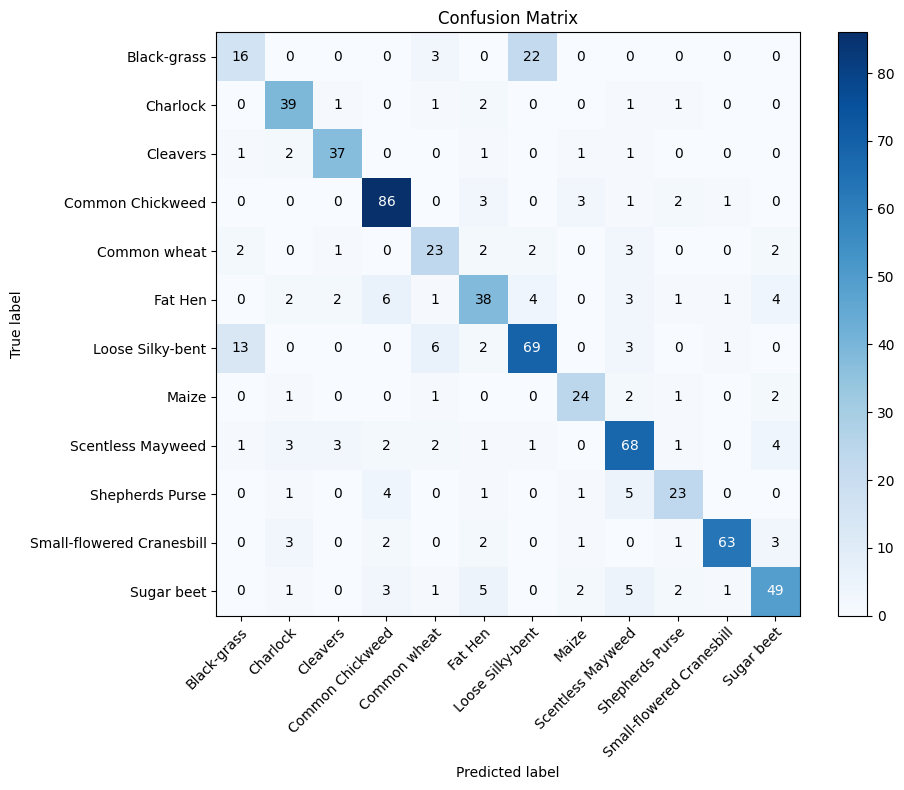

```python
# Make predictions on the validation set
y_pred = model_1.predict(X_val)
y_pred_labels = np.argmax(y_pred, axis=1)

# Calculate accuracy
accuracy = accuracy_score(y_val, y_pred_labels)
print(f'Accuracy: {accuracy:.2f}')

# Generate a classification report with precision and recall for each class
report = classification_report(y_val, y_pred_labels, target_names=unique_labels(labels['Label']))
print("Classification Report:\n", report)

# Calculate and plot the confusion matrix
confusion_mat = confusion_matrix(y_val, y_pred_labels)
classes = unique_labels(labels['Label'])

fig, ax = plt.subplots(figsize=(10, 8))
im = ax.imshow(confusion_mat, interpolation='nearest', cmap=plt.cm.Blues)
ax.figure.colorbar(im, ax=ax)
ax.set(xticks=np.arange(confusion_mat.shape[1]),
       yticks=np.arange(confusion_mat.shape[0]),
       xticklabels=classes, yticklabels=classes,
       title='Confusion Matrix',
       ylabel='True label',
       xlabel='Predicted label')
plt.setp(ax.get_xticklabels(), rotation=45, ha="right", rotation_mode="anchor")
fmt = 'd'
thresh = confusion_mat.max() / 2.
for i in range(confusion_mat.shape[0]):
    for j in range(confusion_mat.shape[1]):
        ax.text(j, i, format(confusion_mat[i, j], fmt),
                ha="center", va="center",
                color="white" if confusion_mat[i, j] > thresh else "black")
fig.tight_layout()
plt.show()
```

This model has perfect accuracy on the training set but only .75 on validation set. This suggests the model might be overfitted.

## Model Performance Improvement

**Reducing the Learning Rate:**

**Hint**: Use **ReduceLRonPlateau()** function that will be used to decrease the learning rate by some factor, if the loss is not decreasing for some time. This may start decreasing the loss at a smaller learning rate. There is a possibility that the loss may still not decrease. This may lead to executing the learning rate reduction again in an attempt to achieve a lower loss.

```python
# Define a simple CNN model
model_2 = keras.Sequential([
    keras.layers.Conv2D(32, (3, 3), activation='relu', input_shape=(64, 64, 3)),
    keras.layers.MaxPooling2D((2, 2)),
    keras.layers.Conv2D(64, (3, 3), activation='relu'),
    keras.layers.MaxPooling2D((2, 2)),
    keras.layers.Conv2D(64, (3, 3), activation='relu', padding='same'),
    keras.layers.MaxPooling2D((2, 2)),
    keras.layers.Conv2D(64, (3, 3), activation='relu', padding='same'),
    keras.layers.MaxPooling2D((2, 2)),
    keras.layers.Conv2D(64, (3, 3), activation='relu', padding='same'),
    keras.layers.MaxPooling2D((2, 2)),
    keras.layers.Conv2D(64, (3, 3), activation='relu', padding='same'),
    keras.layers.Flatten(),
    keras.layers.Dense(64, activation='relu'),
    keras.layers.Dense(12, activation='softmax')
])

# Compile the model
model_2.compile(optimizer='adam',
              loss='sparse_categorical_crossentropy',
              metrics=['accuracy'])

# Define the ReduceLROnPlateau callback
reduce_lr = ReduceLROnPlateau(monitor='val_loss', factor=0.2, patience=3, min_lr=1e-6, verbose=1)

# Train the model with the callback
history = model_2.fit(X_train, y_train, epochs=50, validation_data=(X_val, y_val), callbacks=[reduce_lr])
```

```
Epoch 14: ReduceLROnPlateau reducing learning rate to 0.00020000000949949026.
Epoch 18: ReduceLROnPlateau reducing learning rate to 4.0000001899898055e-05.
Epoch 21: ReduceLROnPlateau reducing learning rate to 8.000000525498762e-06.
Epoch 24: ReduceLROnPlateau reducing learning rate to 1.6000001778593287e-06.
Epoch 27: ReduceLROnPlateau reducing learning rate to 1e-06.
```

```
Accuracy: 0.78
Classification Report:
                            precision    recall  f1-score   support

              Black-grass       0.45      0.49      0.47        41
                 Charlock       0.81      0.84      0.83        45
                 Cleavers       0.80      0.81      0.80        43
         Common Chickweed       0.91      0.91      0.91        96
             Common wheat       0.80      0.69      0.74        35
                  Fat Hen       0.72      0.79      0.75        62
         Loose Silky-bent       0.75      0.77      0.76        94
                    Maize       0.78      0.81      0.79        31
        Scentless Mayweed       0.81      0.83      0.82        86
          Shepherds Purse       0.77      0.66      0.71        35
Small-flowered Cranesbill       0.89      0.84      0.86        75
               Sugar beet       0.77      0.74      0.76        69

                 accuracy                           0.78       712
                macro avg       0.77      0.76      0.77       712
             weighted avg       0.79      0.78      0.78       712
```

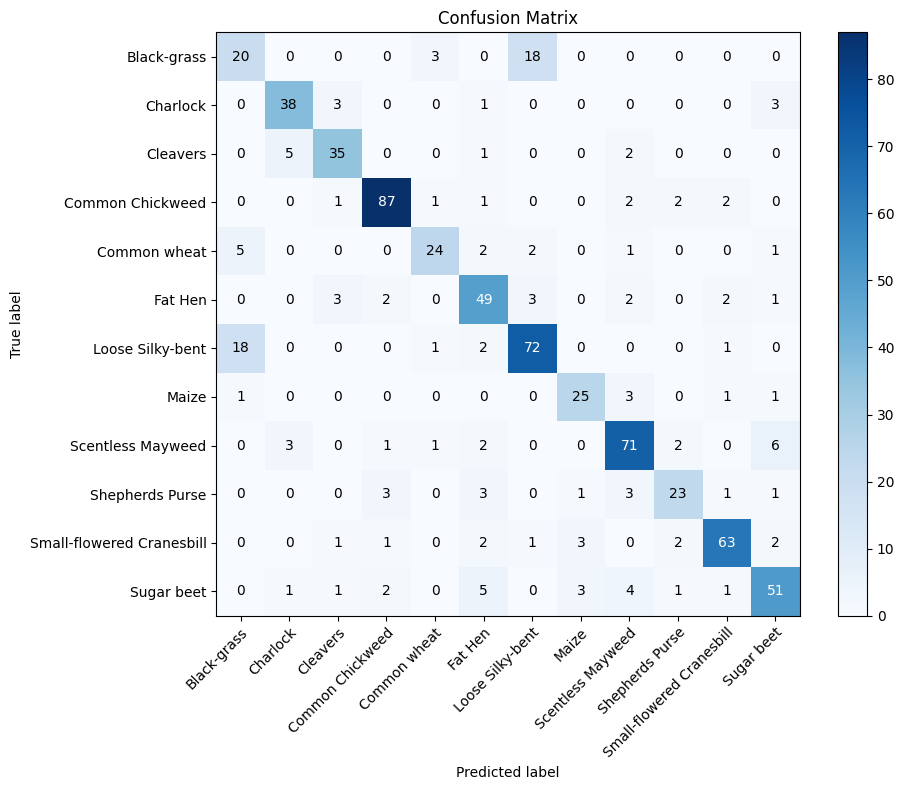

```python
# Make predictions on the validation set
y_pred = model_2.predict(X_val)
y_pred_labels = np.argmax(y_pred, axis=1)

# Calculate accuracy
accuracy = accuracy_score(y_val, y_pred_labels)
print(f'Accuracy: {accuracy:.2f}')

# Generate a classification report with precision and recall for each class
report = classification_report(y_val, y_pred_labels, target_names=unique_labels(labels['Label']))
print("Classification Report:\n", report)

# Calculate and plot the confusion matrix
confusion_mat = confusion_matrix(y_val, y_pred_labels)
classes = unique_labels(labels['Label'])

fig, ax = plt.subplots(figsize=(10, 8))
im = ax.imshow(confusion_mat, interpolation='nearest', cmap=plt.cm.Blues)
ax.figure.colorbar(im, ax=ax)
ax.set(xticks=np.arange(confusion_mat.shape[1]),
       yticks=np.arange(confusion_mat.shape[0]),
       xticklabels=classes, yticklabels=classes,
       title='Confusion Matrix',
       ylabel='True label',
       xlabel='Predicted label')
plt.setp(ax.get_xticklabels(), rotation=45, ha="right", rotation_mode="anchor")
fmt = 'd'
thresh = confusion_mat.max() / 2.
for i in range(confusion_mat.shape[0]):
    for j in range(confusion_mat.shape[1]):
        ax.text(j, i, format(confusion_mat[i, j], fmt),
                ha="center", va="center",
                color="white" if confusion_mat[i, j] > thresh else "black")
fig.tight_layout()
plt.show()
```

.95 accuracy for training set and .78 for validation set. This is a better model.

Using transfer learning:

```python
# Load the VGG16 model with pre-trained weights (excluding the top layers)
base_model = VGG16(weights='imagenet', include_top=False, input_shape=(64, 64, 3))

# Freeze the pre-trained layers
for layer in base_model.layers:
    layer.trainable = False

# Add custom layers on top of the VGG16 base model
x = Flatten()(base_model.output)
x = Dense(128, activation='relu')(x)
x = Dense(12, activation='softmax')(x)

# Create the transfer learning model
model_3 = Model(base_model.input, x)

# Compile the model
model_3.compile(optimizer='adam',
              loss='sparse_categorical_crossentropy',
              metrics=['accuracy'])

# Train the model
history = model_3.fit(X_train, y_train, epochs=50, validation_data=(X_test, y_test))
```

```
Accuracy: 0.62
Classification Report:
                            precision    recall  f1-score   support

              Black-grass       0.50      0.37      0.42        41
                 Charlock       0.52      0.60      0.56        45
                 Cleavers       0.55      0.53      0.54        43
         Common Chickweed       0.74      0.81      0.78        96
             Common wheat       0.53      0.46      0.49        35
                  Fat Hen       0.42      0.40      0.41        62
         Loose Silky-bent       0.64      0.74      0.69        94
                    Maize       0.73      0.61      0.67        31
        Scentless Mayweed       0.69      0.67      0.68        86
          Shepherds Purse       0.35      0.34      0.35        35
Small-flowered Cranesbill       0.68      0.73      0.71        75
               Sugar beet       0.68      0.58      0.63        69

                 accuracy                           0.62       712
                macro avg       0.59      0.57      0.58       712
             weighted avg       0.61      0.62      0.61       712
```

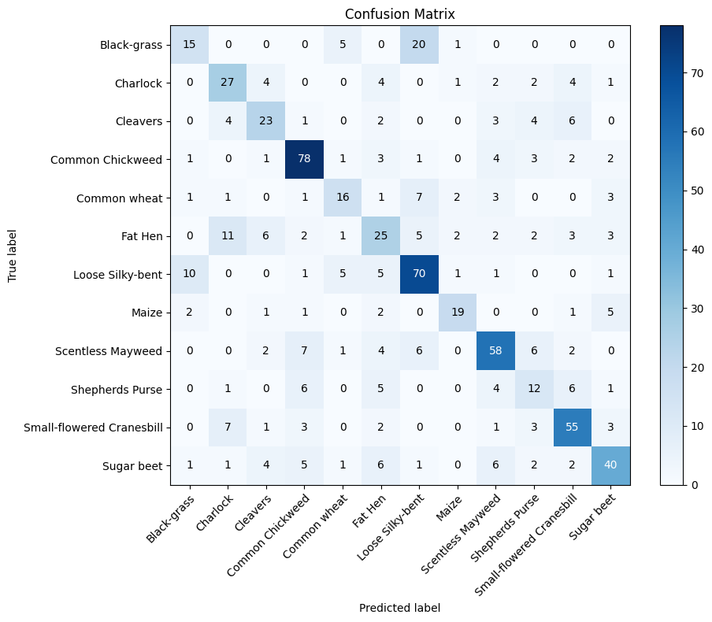

```python
# Make predictions on the validation set
y_pred = model_3.predict(X_val)
y_pred_labels = np.argmax(y_pred, axis=1)

# Calculate accuracy
accuracy = accuracy_score(y_val, y_pred_labels)
print(f'Accuracy: {accuracy:.2f}')

# Generate a classification report with precision and recall for each class
report = classification_report(y_val, y_pred_labels, target_names=unique_labels(labels['Label']))
print("Classification Report:\n", report)

# Calculate and plot the confusion matrix
confusion_mat = confusion_matrix(y_val, y_pred_labels)
classes = unique_labels(labels['Label'])

fig, ax = plt.subplots(figsize=(10, 8))
im = ax.imshow(confusion_mat, interpolation='nearest', cmap=plt.cm.Blues)
ax.figure.colorbar(im, ax=ax)
ax.set(xticks=np.arange(confusion_mat.shape[1]),
       yticks=np.arange(confusion_mat.shape[0]),
       xticklabels=classes, yticklabels=classes,
       title='Confusion Matrix',
       ylabel='True label',
       xlabel='Predicted label')
plt.setp(ax.get_xticklabels(), rotation=45, ha="right", rotation_mode="anchor")
fmt = 'd'
thresh = confusion_mat.max() / 2.
for i in range(confusion_mat.shape[0]):
    for j in range(confusion_mat.shape[1]):
        ax.text(j, i, format(confusion_mat[i, j], fmt),
                ha="center", va="center",
                color="white" if confusion_mat[i, j] > thresh else "black")
fig.tight_layout()
plt.show()
```

This model has .97 for for training set but only .62 for validation. This is the worst model.

### **Data Augmentation**

Remember, **data augmentation should not be used in the validation/test data set**.

```python
# Define a simple CNN model
model_4 = keras.Sequential([
    keras.layers.Conv2D(32, (3, 3), activation='relu', input_shape=(64, 64, 3)),
    keras.layers.MaxPooling2D((2, 2)),
    keras.layers.Conv2D(64, (3, 3), activation='relu'),
    keras.layers.MaxPooling2D((2, 2)),
    keras.layers.Conv2D(64, (3, 3), activation='relu', padding='same'),
    keras.layers.MaxPooling2D((2, 2)),
    keras.layers.Conv2D(64, (3, 3), activation='relu', padding='same'),
    keras.layers.MaxPooling2D((2, 2)),
    keras.layers.Conv2D(64, (3, 3), activation='relu', padding='same'),
    keras.layers.MaxPooling2D((2, 2)),
    keras.layers.Conv2D(64, (3, 3), activation='relu', padding='same'),
    keras.layers.Flatten(),
    keras.layers.Dense(64, activation='relu'),
    keras.layers.Dense(12, activation='softmax')
])

# Create an instance of ImageDataGenerator with augmentation settings
datagen = ImageDataGenerator(
    rotation_range=40,
    width_shift_range=0.2,
    height_shift_range=0.2,
    shear_range=0.2,
    zoom_range=0.2,
    horizontal_flip=True,
    brightness_range=(0.5, 1.5),  # Adjust brightness
    fill_mode='nearest'  # How to fill newly created pixels
)

# Fit the ImageDataGenerator on the data
datagen.fit(X_train)

# Create an iterator for augmented data
augmented_data_iterator = datagen.flow(X_train, y_train, batch_size=32)

# Compile the model
model_4.compile(optimizer='adam',
              loss='sparse_categorical_crossentropy',
              metrics=['accuracy'])

# Define the ReduceLROnPlateau callback
reduce_lr = ReduceLROnPlateau(monitor='val_loss', factor=0.2, patience=3, min_lr=1e-6, verbose=1)

# Train the model with the callback
history = model_4.fit(augmented_data_iterator, epochs=50, validation_data=(X_val, y_val), callbacks=[reduce_lr])
```

```
Epoch 30: ReduceLROnPlateau reducing learning rate to 0.00020000000949949026.
Epoch 38: ReduceLROnPlateau reducing learning rate to 4.0000001899898055e-05.
Epoch 50: ReduceLROnPlateau reducing learning rate to 8.000000525498762e-06.
```

```
Accuracy: 0.84
Classification Report:
                            precision    recall  f1-score   support

              Black-grass       0.44      0.56      0.49        41
                 Charlock       0.80      0.89      0.84        45
                 Cleavers       0.77      0.86      0.81        43
         Common Chickweed       0.93      0.94      0.93        96
             Common wheat       0.80      0.80      0.80        35
                  Fat Hen       0.91      0.81      0.85        62
         Loose Silky-bent       0.78      0.64      0.70        94
                    Maize       0.81      0.97      0.88        31
        Scentless Mayweed       0.90      0.87      0.89        86
          Shepherds Purse       0.82      0.77      0.79        35
Small-flowered Cranesbill       0.95      0.97      0.96        75
               Sugar beet       0.91      0.90      0.91        69

                 accuracy                           0.84       712
                macro avg       0.82      0.83      0.82       712
             weighted avg       0.84      0.84      0.84       712
```

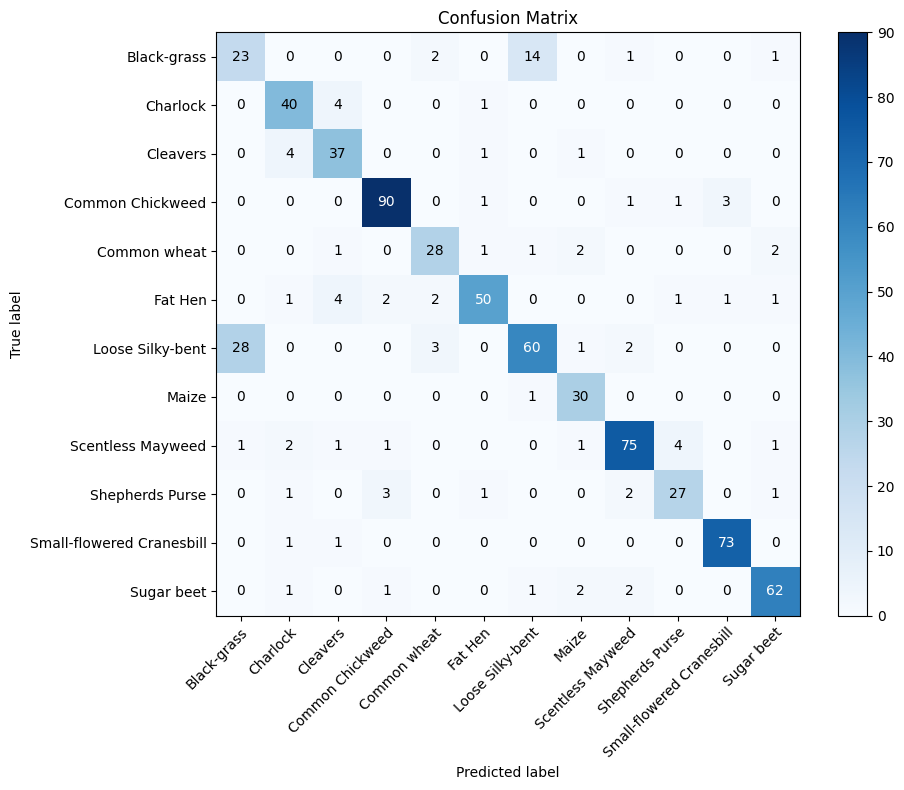

```python
# Make predictions on the validation set
y_pred = model_4.predict(X_val)
y_pred_labels = np.argmax(y_pred, axis=1)

# Calculate accuracy
accuracy = accuracy_score(y_val, y_pred_labels)
print(f'Accuracy: {accuracy:.2f}')

# Generate a classification report with precision and recall for each class
report = classification_report(y_val, y_pred_labels, target_names=unique_labels(labels['Label']))
print("Classification Report:\n", report)

# Calculate and plot the confusion matrix
confusion_mat = confusion_matrix(y_val, y_pred_labels)
classes = unique_labels(labels['Label'])

fig, ax = plt.subplots(figsize=(10, 8))
im = ax.imshow(confusion_mat, interpolation='nearest', cmap=plt.cm.Blues)
ax.figure.colorbar(im, ax=ax)
ax.set(xticks=np.arange(confusion_mat.shape[1]),
       yticks=np.arange(confusion_mat.shape[0]),
       xticklabels=classes, yticklabels=classes,
       title='Confusion Matrix',
       ylabel='True label',
       xlabel='Predicted label')
plt.setp(ax.get_xticklabels(), rotation=45, ha="right", rotation_mode="anchor")
fmt = 'd'
thresh = confusion_mat.max() / 2.
for i in range(confusion_mat.shape[0]):
    for j in range(confusion_mat.shape[1]):
        ax.text(j, i, format(confusion_mat[i, j], fmt),
                ha="center", va="center",
                color="white" if confusion_mat[i, j] > thresh else "black")
fig.tight_layout()
plt.show()
```

## Final Model

Comment on the final model you have selected and use the same in the below code to visualize the image.

I have chosen the model with reduced learning rate and augmented data because that had the highest score on valication set.

```python
# Define a simple CNN model
final_model = keras.Sequential([
    keras.layers.Conv2D(32, (3, 3), activation='relu', input_shape=(64, 64, 3)),
    keras.layers.MaxPooling2D((2, 2)),
    keras.layers.Conv2D(64, (3, 3), activation='relu'),
    keras.layers.MaxPooling2D((2, 2)),
    keras.layers.Conv2D(64, (3, 3), activation='relu', padding='same'),
    keras.layers.MaxPooling2D((2, 2)),
    keras.layers.Conv2D(64, (3, 3), activation='relu', padding='same'),
    keras.layers.MaxPooling2D((2, 2)),
    keras.layers.Conv2D(64, (3, 3), activation='relu', padding='same'),
    keras.layers.MaxPooling2D((2, 2)),
    keras.layers.Conv2D(64, (3, 3), activation='relu', padding='same'),
    keras.layers.Flatten(),
    keras.layers.Dense(64, activation='relu'),
    keras.layers.Dense(12, activation='softmax')
])

# Create an instance of ImageDataGenerator with augmentation settings
datagen = ImageDataGenerator(
    rotation_range=40,
    width_shift_range=0.2,
    height_shift_range=0.2,
    shear_range=0.2,
    zoom_range=0.2,
    horizontal_flip=True,
    brightness_range=(0.5, 1.5),  # Adjust brightness
    fill_mode='nearest'  # How to fill newly created pixels
)

# Fit the ImageDataGenerator on your data
datagen.fit(X_train)

# Create an iterator for augmented data
augmented_data_iterator = datagen.flow(X_train, y_train, batch_size=32)

# Compile the model
final_model.compile(optimizer='adam',
              loss='sparse_categorical_crossentropy',
              metrics=['accuracy'])

# Define the ReduceLROnPlateau callback
reduce_lr = ReduceLROnPlateau(monitor='val_loss', factor=0.2, patience=3, min_lr=1e-6, verbose=1)

# Train the model with the callback
history = final_model.fit(augmented_data_iterator, epochs=50, validation_data=(X_test, y_test), callbacks=[reduce_lr])
```

```
Epoch 31: ReduceLROnPlateau reducing learning rate to 0.00020000000949949026.
Epoch 37: ReduceLROnPlateau reducing learning rate to 4.0000001899898055e-05.
Epoch 48: ReduceLROnPlateau reducing learning rate to 8.000000525498762e-06.
```

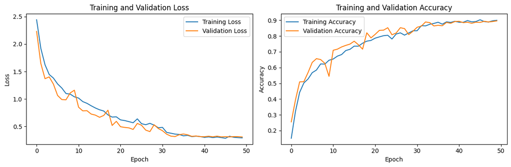

```python
# Access the training history
training_loss = history.history['loss']
validation_loss = history.history['val_loss']
training_accuracy = history.history['accuracy']
validation_accuracy = history.history['val_accuracy']

# Create subplots for loss and accuracy
plt.figure(figsize=(12, 4))

# Plot training and validation loss
plt.subplot(1, 2, 1)
plt.plot(training_loss, label='Training Loss')
plt.plot(validation_loss, label='Validation Loss')
plt.title('Training and Validation Loss')
plt.xlabel('Epoch')
plt.ylabel('Loss')
plt.legend()

# Plot training and validation accuracy
plt.subplot(1, 2, 2)
plt.plot(training_accuracy, label='Training Accuracy')
plt.plot(validation_accuracy, label='Validation Accuracy')
plt.title('Training and Validation Accuracy')
plt.xlabel('Epoch')
plt.ylabel('Accuracy')
plt.legend()

# Show the plots
plt.tight_layout()
plt.show()
```

### Visualizing the prediction

```
Accuracy: 0.90
Classification Report:
                            precision    recall  f1-score   support

              Black-grass       0.45      0.61      0.52        38
                 Charlock       0.90      0.99      0.94        72
                 Cleavers       0.93      0.95      0.94        43
         Common Chickweed       0.97      0.97      0.97        87
             Common wheat       0.90      0.84      0.87        31
                  Fat Hen       0.99      0.91      0.95        81
         Loose Silky-bent       0.86      0.75      0.80       102
                    Maize       0.97      0.89      0.93        35
        Scentless Mayweed       0.88      0.99      0.93        69
          Shepherds Purse       0.97      0.85      0.91        34
Small-flowered Cranesbill       0.97      0.95      0.96        74
               Sugar beet       0.94      0.98      0.96        47

                 accuracy                           0.90       713
                macro avg       0.89      0.89      0.89       713
             weighted avg       0.91      0.90      0.90       713
```

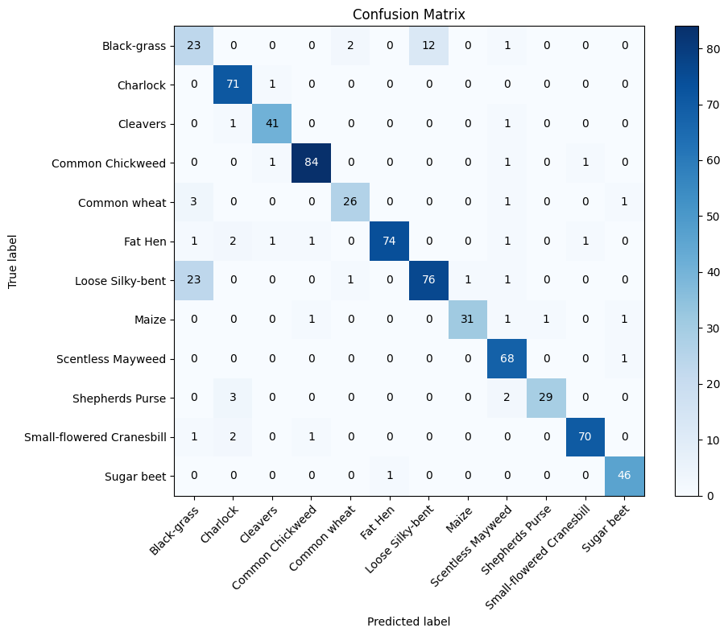

```python
# Make predictions on the test set
y_pred = final_model.predict(X_test)
y_pred_labels = np.argmax(y_pred, axis=1)

# Calculate accuracy
accuracy = accuracy_score(y_test, y_pred_labels)
print(f'Accuracy: {accuracy:.2f}')

# Generate a classification report with precision and recall for each class
report = classification_report(y_test, y_pred_labels, target_names=unique_labels(labels['Label']))
print("Classification Report:\n", report)

# Calculate and plot the confusion matrix
confusion_mat = confusion_matrix(y_test, y_pred_labels)
classes = unique_labels(labels['Label'])

fig, ax = plt.subplots(figsize=(10, 8))
im = ax.imshow(confusion_mat, interpolation='nearest', cmap=plt.cm.Blues)
ax.figure.colorbar(im, ax=ax)
ax.set(xticks=np.arange(confusion_mat.shape[1]),
       yticks=np.arange(confusion_mat.shape[0]),
       xticklabels=classes, yticklabels=classes,
       title='Confusion Matrix',
       ylabel='True label',
       xlabel='Predicted label')
plt.setp(ax.get_xticklabels(), rotation=45, ha="right", rotation_mode="anchor")
fmt = 'd'
thresh = confusion_mat.max() / 2.
for i in range(confusion_mat.shape[0]):
    for j in range(confusion_mat.shape[1]):
        ax.text(j, i, format(confusion_mat[i, j], fmt),
                ha="center", va="center",
                color="white" if confusion_mat[i, j] > thresh else "black")
fig.tight_layout()
plt.show()
```

This model has a decent 90% accuracy when applied to testing set. It's not perfect, for example it only had .61 recall score for Black-grass.

## Actionable Insights and Business Recommendations

I would like to propose a potential avenue for further improving the model's performance. It has come to my attention that certain seed types within the dataset exhibit a high degree of visual similarity, which has presented challenges in accurately distinguishing between them. To address this issue, I recommend considering a more comprehensive data gathering approach.

By obtaining a more diverse and extensive set of images for these closely related seed types, we can provide the model with a richer and more discriminative dataset. This increased diversity can enable the model to better capture the subtle visual distinctions that may exist between these seed types, ultimately leading to improved accuracy and robustness in classification.

Additionally, an expanded dataset can contribute to enhanced model generalization, making it more adept at handling variations and unforeseen instances in real-world scenarios. I believe that investing in better data gathering practices can be a valuable step toward achieving our goal of further enhancing the model's performance and accuracy.

```python
%%shell
jupyter nbconvert /content/drive/MyDrive/High_Code_Plant_Seedling_Classification.ipynb --to html
```

```
[NbConvertApp] Converting notebook /content/drive/MyDrive/High_Code_Plant_Seedling_Classification.ipynb to html
[NbConvertApp] Writing 2498950 bytes to /content/drive/MyDrive/High_Code_Plant_Seedling_Classification.html
```